# Mania_Modelling

## ADHD

```r
adhd <- read_csv("E:/release_5.1/core/mental-health/mh_p_cbcl.csv")
adhd = subset(adhd, select = c("src_subject_id", "eventname", "cbcl_scr_dsm5_adhd_t", "cbcl_scr_dsm5_adhd_r"))
# Use only baseline
adhd = subset(adhd, adhd$eventname == "baseline_year_1_arm_1")
```

### PLOT ADHD CBCL DSM5 Scale t-score

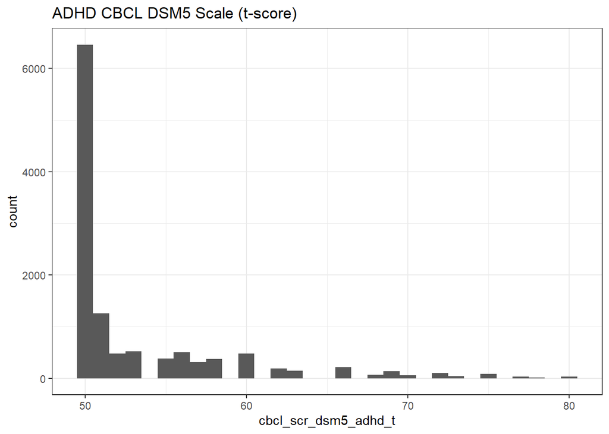

```r
ggplot(adhd, aes(x = cbcl_scr_dsm5_adhd_t))+
  geom_histogram(binwidth = 1)+
  ggtitle("ADHD CBCL DSM5 Scale (t-score)")
```

```r
# mean and range
mean(na.omit(adhd$cbcl_scr_dsm5_adhd_t))
```

```
## [1] 53.22816
```

```r
sd(na.omit(adhd$cbcl_scr_dsm5_adhd_t))
```

```
## [1] 5.635218
```

```r
table(adhd$cbcl_scr_dsm5_adhd_t)
```

```
##
##   50   51   52   53   55   56   57   58   60   62   63   66   68   69   70   72
## 6462 1257  480  518  381  502  308  372  479  192  147  211   70  133   54   99
##   73   75   77   78   80
##   39   84   29   15   28
```

### PLOT ADHD CBCL DSM5 Scale raw-score

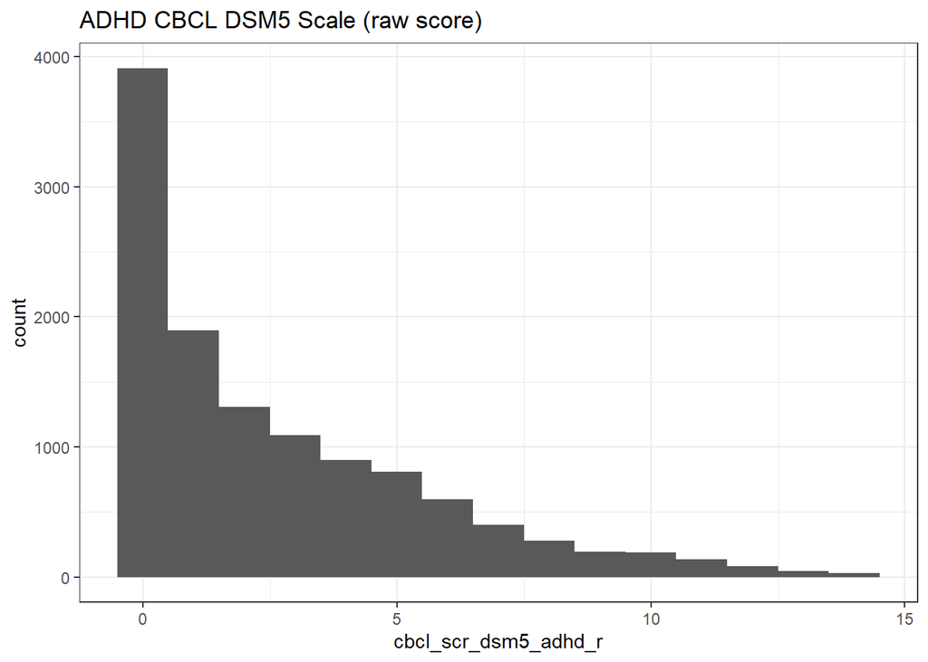

```r
ggplot(adhd, aes(x = cbcl_scr_dsm5_adhd_r))+
  geom_histogram(binwidth = 1)+
  ggtitle("ADHD CBCL DSM5 Scale (raw score)")
```

```r
# mean and range
mean(na.omit(adhd$cbcl_scr_dsm5_adhd_r))
```

```
## [1] 2.62597
```

```r
sd(na.omit(adhd$cbcl_scr_dsm5_adhd_r))
```

```
## [1] 2.974309
```

```r
table(adhd$cbcl_scr_dsm5_adhd_r)
```

```
##
##    0    1    2    3    4    5    6    7    8    9   10   11   12   13   14
## 3912 1893 1305 1089  899  810  597  401  278  195  187  138   84   44   28
```

## Oppossitional Defiant Disorder

```r
opposition <- read_csv("E:/release_5.1/core/mental-health/mh_p_cbcl.csv")
opposition = subset(opposition, select = c("src_subject_id", "eventname", "cbcl_scr_dsm5_opposit_t", "cbcl_scr_dsm5_opposit_r"))
# Use only baseline
opposition = subset(opposition, opposition$eventname == "baseline_year_1_arm_1")
```

### PLOT CBCL opposition DSM5 scale t-score

[figure not shown]

```r
ggplot(opposition, aes(x = cbcl_scr_dsm5_opposit_t))+
  geom_histogram(binwidth = 1)+
  ggtitle("ADHD CBCL DSM5 Scale (t-score)")
```

```r
# mean and range
mean(na.omit(opposition$cbcl_scr_dsm5_opposit_t))
```

```
## [1] 53.47462
```

```r
sd(na.omit(opposition$cbcl_scr_dsm5_opposit_t))
```

```
## [1] 5.416052
```

```r
table(opposition$cbcl_scr_dsm5_opposit_t)
```

```
##
##   50   51   52   55   58   59   62   63   66   67   70   73   77   80
## 4670 1976 1640 1298  588  431  367  212  177  102  171  125   77   26
```

### PLOT CBCL opposition DSM5 scale raw score

[figure not shown]

```r
ggplot(opposition, aes(x = cbcl_scr_dsm5_opposit_r))+
  geom_histogram(binwidth = 1)+
  ggtitle("ADHD CBCL DSM5 Scale (raw score)")
```

```r
# mean and range
mean(na.omit(opposition$cbcl_scr_dsm5_opposit_r))
```

```
## [1] 1.76602
```

```r
sd(na.omit(opposition$cbcl_scr_dsm5_opposit_r))
```

```
## [1] 2.038249
```

```r
table(opposition$cbcl_scr_dsm5_opposit_r)
```

```
##
##    0    1    2    3    4    5    6    7    8    9   10
## 4670 1976 1640 1298 1019  579  279  171  125   77   26
```

## Conduct Disorder

```r
conduct <- read_csv("E:/release_5.1/core/mental-health/mh_p_cbcl.csv")
conduct = subset(conduct, select = c("src_subject_id", "eventname", "cbcl_scr_dsm5_conduct_t", "cbcl_scr_dsm5_conduct_r"))
# Use only baseline
conduct = subset(conduct, conduct$eventname == "baseline_year_1_arm_1")
```

### PLOT CBCL conduct DSM5 scale t-score

[figure not shown]

```r
ggplot(conduct, aes(x = cbcl_scr_dsm5_conduct_t))+
  geom_histogram(binwidth = 1)+
  ggtitle("ADHD CBCL DSM5 Scale (t-score)")
```

```r
# mean and range
mean(na.omit(conduct$cbcl_scr_dsm5_conduct_t))
```

```
## [1] 53.02732
```

```r
sd(na.omit(conduct$cbcl_scr_dsm5_conduct_t))
```

```
## [1] 5.529743
```

```r
table(conduct$cbcl_scr_dsm5_conduct_t)
```

```
##
##   50   51   52   54   56   57   60   63   65   66   67   69   70   71   72   73
## 6730 1072  868  695  459  401  531  335  121   94   94  128   82   65   48   11
##   74   75   76   77   78   79   80   81   82   83   84   86   89
##   34   17   16   11   15    1   11    7    5    2    2    4    1
```

### PLOT CBCL conduct DSM5 scale raw score

[figure not shown]

```r
ggplot(conduct, aes(x = cbcl_scr_dsm5_conduct_r))+
  geom_histogram(binwidth = 1)+
  ggtitle("ADHD CBCL DSM5 Scale (raw score)")
```

```r
# mean and range
mean(na.omit(conduct$cbcl_scr_dsm5_conduct_r))
```

```
## [1] 1.283558
```

```r
sd(na.omit(conduct$cbcl_scr_dsm5_conduct_r))
```

```
## [1] 2.355664
```

```r
table(conduct$cbcl_scr_dsm5_conduct_r)
```

```
##
##    0    1    2    3    4    5    6    7    8    9   10   11   12   13   14   15
## 6730 1940 1154  663  430  268  188  133   95   64   42   45   23   22   14    7
##   16   17   18   19   20   21   22   25
##   15    7    8    4    2    1    4    1
```

## Chronic stress/ stressful life events

```r
stress <- read_csv("E:/release_5.1/core/mental-health/mh_p_cbcl.csv")
stress = subset(stress, select = c("src_subject_id", "eventname", "cbcl_scr_07_stress_t", "cbcl_scr_07_stress_r"))
stress = subset(stress, stress$eventname == "baseline_year_1_arm_1") # select only baseline
```

### PLOT Stress t-score

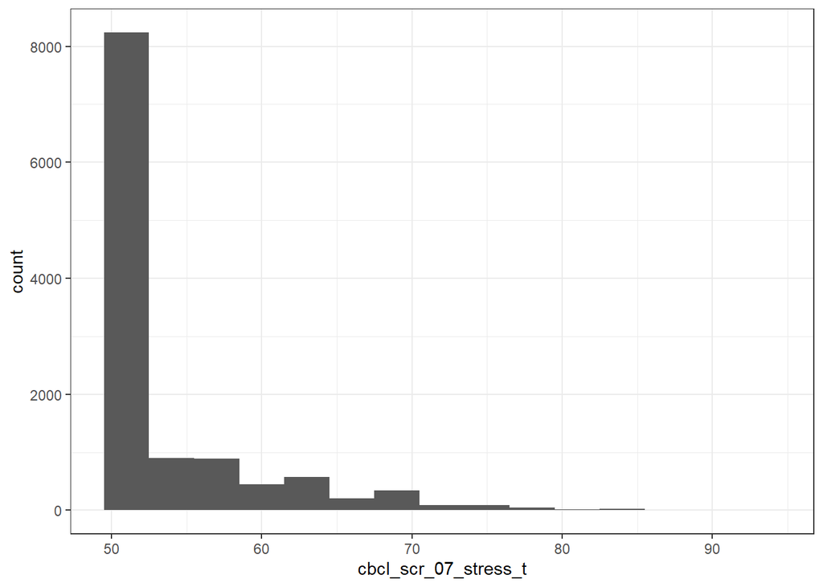

```r
# plot
ggplot(stress, aes(x = cbcl_scr_07_stress_t))+
  geom_histogram(binwidth = 3)
```

```r
# mean and range
mean(na.omit(stress$cbcl_scr_07_stress_t))
```

```
## [1] 53.32589
```

```r
sd(na.omit(stress$cbcl_scr_07_stress_t))
```

```
## [1] 6.004436
```

```r
table(stress$cbcl_scr_07_stress_t)
```

```
##
##   50   51   54   56   57   58   59   61   62   63   64   66   68   69   70   72
## 7033 1203  903  291  375  220  286  164  213  123  235  205  105  151   89   83
##   74   76   78   79   81   83   85   87   89   93
##   60   33   25   24   11    8   12    4    2    2
```

### PLOT Stress raw score

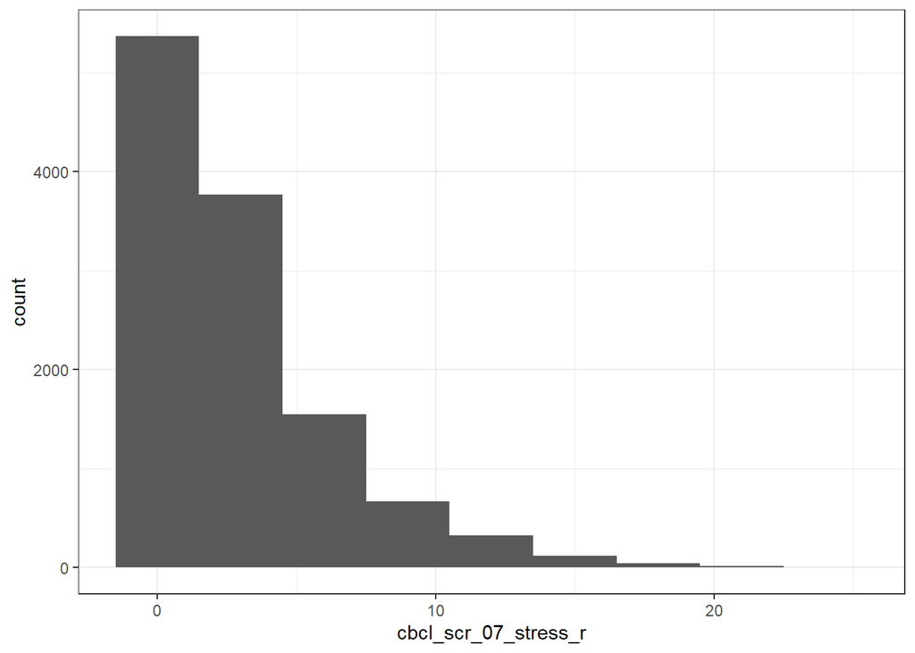

```r
# plot
ggplot(stress, aes(x = cbcl_scr_07_stress_r))+
  geom_histogram(binwidth = 3)
```

```r
# mean and range
mean(na.omit(stress$cbcl_scr_07_stress_r))
```

```
## [1] 2.904553
```

```r
sd(na.omit(stress$cbcl_scr_07_stress_r))
```

```
## [1] 3.347713
```

```r
table(stress$cbcl_scr_07_stress_r)
```

```
##
##    0    1    2    3    4    5    6    7    8    9   10   11   12   13   14   15
## 3098 2272 1663 1203  903  666  506  377  270  233  165  151   89   83   60   33
##   16   17   18   19   20   21   22   24
##   25   24   11    8   12    4    2    2
```

# COGNITION

## Verbal memory - Rey Auditory Verbal Learning Test

```r
ravlt<-read_csv("E:/release_5.1/core/neurocognition/nc_y_ravlt.csv")

ravlt<-ravlt %>% filter(str_detect(eventname,'baseline')) %>%
  select(src_subject_id,ends_with("tc"))

#score the RAVLT
ravlt<-ravlt %>% mutate(ravlt_learning=rowSums(across(c(pea_ravlt_sd_trial_i_tc:pea_ravlt_sd_trial_v_tc)),na.rm=T)) %>%
  rename(ravlt_distract=pea_ravlt_sd_listb_tc,
         ravlt_short=pea_ravlt_sd_trial_vi_tc,
         ravlt_long=pea_ravlt_ld_trial_vii_tc)
#remove other variables
ravlt<-ravlt %>% select(src_subject_id,starts_with("ravlt"))
```

### PLOT Verbal Memory “Learning”

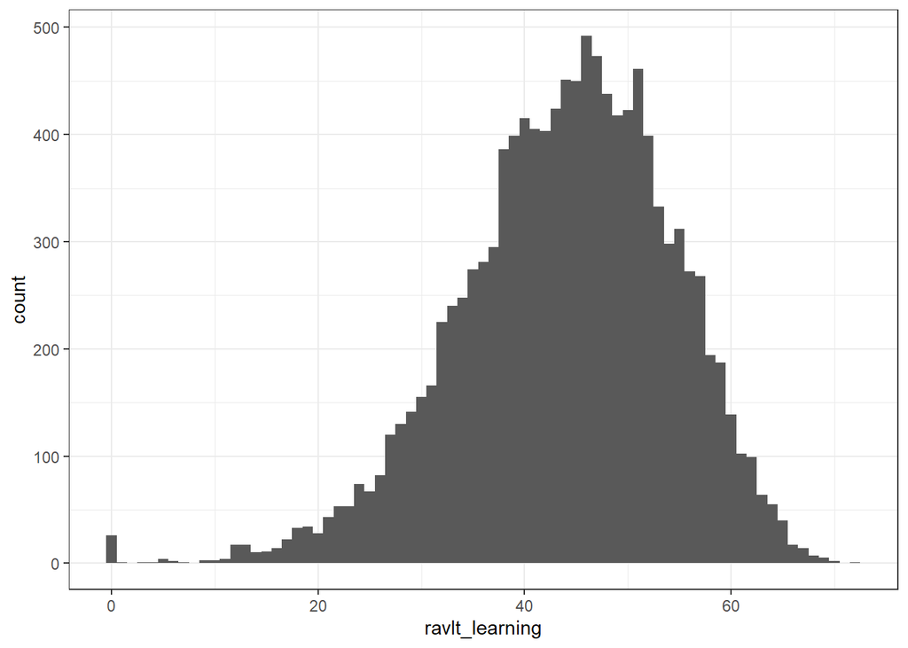

```r
ggplot(ravlt, aes(x = ravlt_learning))+
  geom_histogram(binwidth = 1)
```

```r
# mean and range
mean(na.omit(ravlt$ravlt_learning))
```

```
## [1] 43.93928
```

```r
sd(na.omit(ravlt$ravlt_learning))
```

```
## [1] 10.26204
```

```r
table(ravlt$ravlt_learning)
```

```
##
##   0   1   3   4   5   6   7   9  10  11  12  13  14  15  16  17  18  19  20  21
##  26   1   1   1   4   2   1   3   3   4  17  17  10  11  14  22  33  34  28  43
##  22  23  24  25  26  27  28  29  30  31  32  33  34  35  36  37  38  39  40  41
##  53  53  74  67  82 120 130 141 155 166 225 240 248 274 281 295 386 399 415 405
##  42  43  44  45  46  47  48  49  50  51  52  53  54  55  56  57  58  59  60  61
## 403 424 451 450 492 473 438 418 423 461 399 333 298 312 272 268 194 187 139 102
##  62  63  64  65  66  67  68  69  70  72
##  99  64  55  40  17  14   7   5   2   1
```

# FAMILY

## Family conflict & criticism

```r
conflict_p <- read_csv("E:/release_5.1/core/culture-environment/ce_p_fes.csv")
conflict_p = subset(conflict_p, select = c("src_subject_id", "eventname", "fes_p_ss_fc")) # select relevant variable
conflict_p = subset(conflict_p, conflict_p$eventname == "baseline_year_1_arm_1") # select only baseline

conflict_y <- read_csv("E:/release_5.1/core/culture-environment/ce_y_fes.csv")
conflict_y = subset(conflict_y, select = c("src_subject_id", "eventname", "fes_y_ss_fc")) # select relevant variable
conflict_y = subset(conflict_y, conflict_y$eventname == "baseline_year_1_arm_1") # select only baseline
```

### PLOT Parent Report Sum Score - Family Conflict

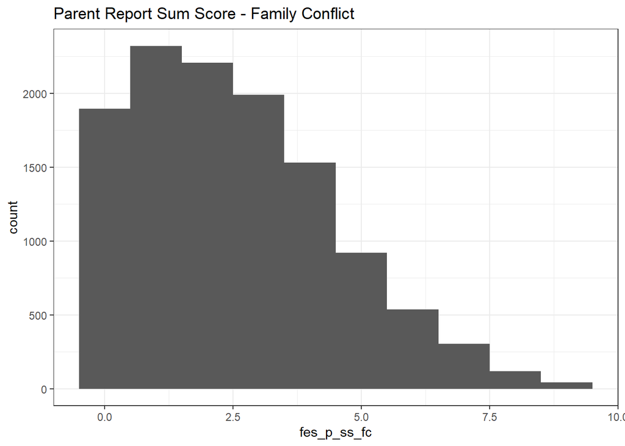

```r
ggplot(conflict_p, aes(x = fes_p_ss_fc))+
  geom_histogram(binwidth = 1)+
  ggtitle("Parent Report Sum Score - Family Conflict")
```

```r
# mean and range
mean(na.omit(conflict_p$fes_p_ss_fc))
```

```
## [1] 2.537593
```

```r
sd(na.omit(conflict_p$fes_p_ss_fc))
```

```
## [1] 1.957253
```

```r
table(conflict_p$fes_p_ss_fc)
```

```
##
##    0    1    2    3    4    5    6    7    8    9
## 1896 2321 2205 1989 1530  921  537  303  118   44
```

### PLOT Youth Report Sum Score - Family Conflict

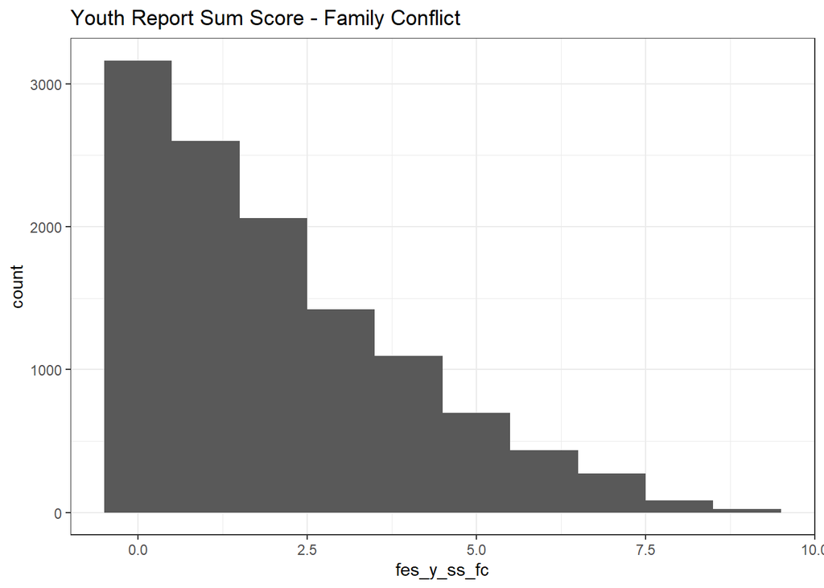

```r
ggplot(conflict_y, aes(x = fes_y_ss_fc))+
  geom_histogram(binwidth = 1)+
  ggtitle("Youth Report Sum Score - Family Conflict")
```

```r
# mean and range
mean(na.omit(conflict_y$fes_y_ss_fc))
```

```
## [1] 2.044917
```

```r
sd(na.omit(conflict_y$fes_y_ss_fc))
```

```
## [1] 1.953831
```

```r
table(conflict_y$fes_y_ss_fc)
```

```
##
##    0    1    2    3    4    5    6    7    8    9
## 3163 2601 2058 1419 1094  695  434  272   85   23
```

## Childhood Trauma

```r
trauma<-read_csv("E:/release_5.1/core/mental-health/mh_p_ksads_ptsd.csv")
trauma<-trauma %>% filter(str_detect(eventname,'baseline')) %>% remove_empty() # select baseline

# create total variable
trauma<- trauma %>% mutate(total_PTSD=rowSums(across(c(ksads_ptsd_raw_754_p: ksads_ptsd_raw_770_p))))

#create maltreatment variable
trauma<- trauma %>% mutate(maltreatment=rowSums(across(c(ksads_ptsd_raw_761_p:ksads_ptsd_raw_765_p,ksads_ptsd_raw_767_p:ksads_ptsd_raw_769_p))))
```

### PLOT Trauma

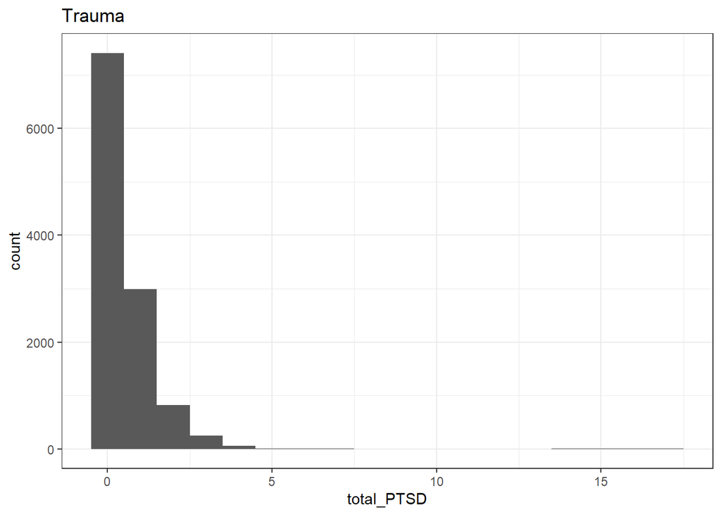

```r
ggplot(trauma, aes(x = total_PTSD))+
  geom_histogram(binwidth = 1)+
  ggtitle("Trauma")
```

```r
# mean and range
mean(na.omit(trauma$total_PTSD))
```

```
## [1] 0.5083074
```

```r
sd(na.omit(trauma$total_PTSD))
```

```
## [1] 0.9318724
```

```r
table(trauma$total_PTSD)
```

```
##
##    0    1    2    3    4    5    6    7   14   15   16   17
## 7415 2994  816  250   51   10    5    3    2    1    3    6
```

## Childhood Maltreatment

Here, I create a new ‘maltreatment’ variable by reversing emotional warmth scores to represent emotional neglect and incorporating maltreatment data from the KSADS.

```r
emotional_warmth<-read_csv("E:/release_5.1/core/culture-environment/ce_y_crpbi.csv")
emotional_warmth<-emotional_warmth %>% filter(str_detect(eventname,'baseline')) %>% remove_empty() # select baseline

# create total variable
emotional_warmth<- emotional_warmth %>% mutate(emo_neglect=rowSums(across(c(crpbi_parent1_y: crpbi_parent5_y))))

# create binary variable (0 = no neglect, 1 = neglect)
# 1 = "not like him" = emotional neglect. 2 or 3 = "somewhat/ a lot like him" = no neglect.
emotional_warmth$crpbi_parent1_y_binary <- ifelse(emotional_warmth$crpbi_parent1_y == 1, 1, 0)
emotional_warmth$crpbi_parent2_y_binary <- ifelse(emotional_warmth$crpbi_parent2_y == 1, 1, 0)
emotional_warmth$crpbi_parent3_y_binary <- ifelse(emotional_warmth$crpbi_parent3_y == 1, 1, 0)
emotional_warmth$crpbi_parent4_y_binary <- ifelse(emotional_warmth$crpbi_parent4_y == 1, 1, 0)
emotional_warmth$crpbi_parent5_y_binary <- ifelse(emotional_warmth$crpbi_parent5_y == 1, 1, 0)

emotional_warmth<- emotional_warmth %>% mutate(emotional_warmth_binary =rowSums(across(c(crpbi_parent1_y_binary: crpbi_parent5_y_binary))))


# select the two necessary datasets
maltreatment_neglect_data = subset(trauma, select = c("src_subject_id", "maltreatment")) # select
maltreatment_neglect_data2 = subset(emotional_warmth, select = c("src_subject_id", "emotional_warmth_binary")) # select

# join the two datasets by subject ID
maltreatment_neglect = full_join(maltreatment_neglect_data, maltreatment_neglect_data2, by = "src_subject_id")

# clean leftover datasets
rm(maltreatment_neglect_data)
rm(maltreatment_neglect_data2)

# check correlation
#cor(na.omit(maltreatment_neglect$maltreatment, maltreatment_neglect$emotional_warmth_binary))

# add into 1 variable
maltreatment_neglect<- maltreatment_neglect %>% mutate(mal_neglect=rowSums(across(c(maltreatment, emotional_warmth_binary))))
```

### PLOT Maltreatment

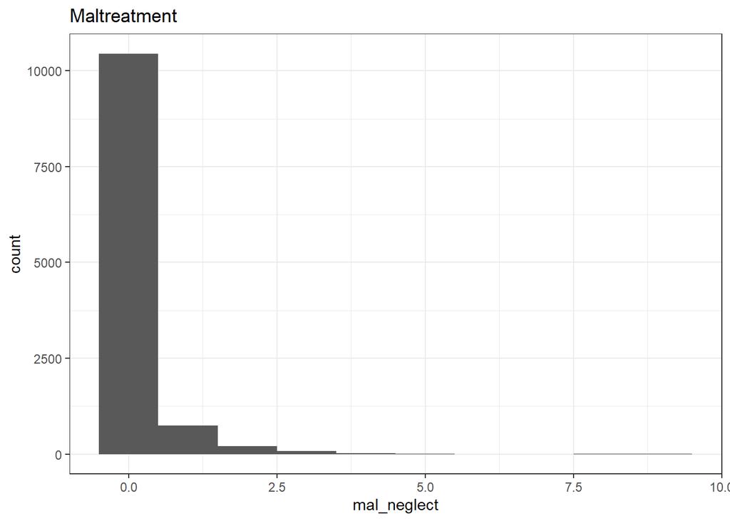

```r
ggplot(maltreatment_neglect, aes(x = mal_neglect))+
  geom_histogram(binwidth = 1)+
  ggtitle("Maltreatment")
```

```r
# mean and range
mean(na.omit(maltreatment_neglect$mal_neglect))
```

```
## [1] 0.1406128
```

```r
sd(na.omit(maltreatment_neglect$mal_neglect))
```

```
## [1] 0.5461519
```

```r
table(maltreatment_neglect$mal_neglect)
```

```
##
##     0     1     2     3     4     5     8     9
## 10450   750   200    76    20    13    11     1
```

## Family history of mania - First-Degree Relatives

They were measured only at baseline! data = fam_first. variable = family_mania

```r
fam_first<-read_csv("E:/release_5.1/core/mental-health/mh_p_fhx.csv")
unique(fam_first$eventname) # => this shows us all data is already only at baseline
```

```
## [1] "baseline_year_1_arm_1"
```

```r
fam_first <- fam_first %>% select(src_subject_id, famhx_ss_fath_prob_ma_p,famhx_ss_moth_prob_ma_p, famhx_ss_fulsiby1_prob_ma_p, famhx_ss_fulsiby2_prob_ma_p, famhx_ss_fulsiby3_prob_ma_p, famhx_ss_fulsiby4_prob_ma_p, famhx_ss_fulsiby5_prob_ma_p, famhx_ss_fulsibo1_prob_ma_p, famhx_ss_fulsibo2_prob_ma_p, famhx_ss_fulsibo3_prob_ma_p, famhx_ss_fulsibo4_prob_ma_p, famhx_ss_fulsibo5_prob_ma_p) # select variables

fam_first<-fam_first %>% mutate(sum_history=rowSums(across(c(famhx_ss_fath_prob_ma_p, famhx_ss_moth_prob_ma_p, famhx_ss_fulsiby1_prob_ma_p, famhx_ss_fulsiby2_prob_ma_p, famhx_ss_fulsiby3_prob_ma_p, famhx_ss_fulsiby4_prob_ma_p, famhx_ss_fulsiby5_prob_ma_p, famhx_ss_fulsibo1_prob_ma_p, famhx_ss_fulsibo2_prob_ma_p, famhx_ss_fulsibo3_prob_ma_p, famhx_ss_fulsibo4_prob_ma_p, famhx_ss_fulsibo5_prob_ma_p)),na.rm=T)) # sum score

fam_first<-fam_first %>% mutate(family_mania=if_else(sum_history>0,1,0))  # binary score (yes/no)
```

### PLOT First-Degree Relatives, Binary

This is the relatives variables that was used in analysis. Still, let’s have a look at other options, too!

```r
table(fam_first$family_mania)#check N of people with family history
```

```
##
##     0     1
## 11242   626
```

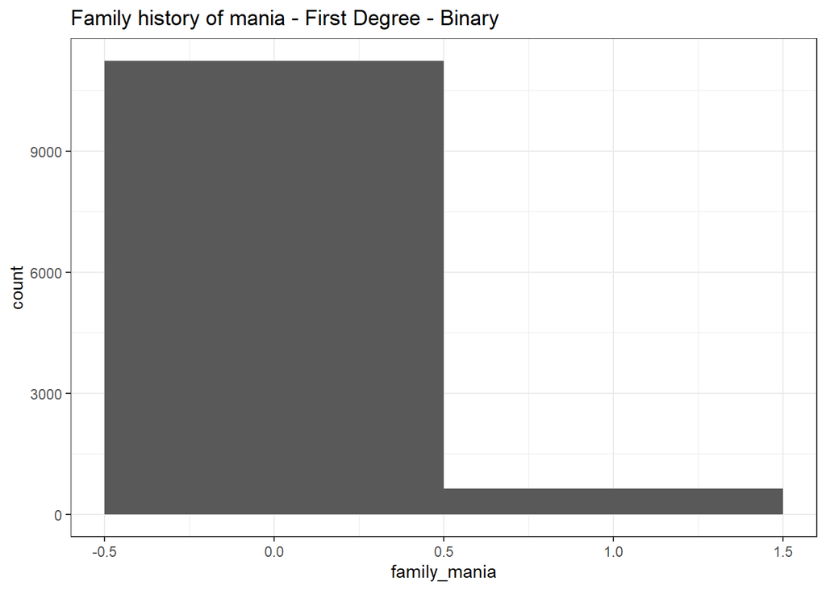

```r
ggplot(fam_first, aes(x = family_mania))+
  geom_histogram(binwidth = 1)+
  ggtitle("Family history of mania - First Degree - Binary")
```

### PLOT First-Degree Relatives, Sum Score

```r
table(fam_first$sum_history) # sum score
```

```
##
##     0     1     2     3     4
## 11242   571    49     5     1
```

```r
mean(fam_first$sum_history)
```

```
## [1] 0.05797101
```

```r
sd(fam_first$sum_history)
```

```
## [1] 0.257706
```

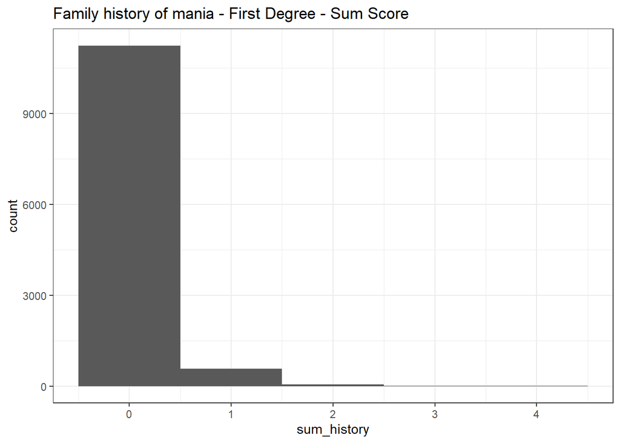

```r
ggplot(fam_first, aes(x = sum_history))+
  geom_histogram(binwidth = 1)+
  ggtitle("Family history of mania - First Degree - Sum Score")
```

## Family history of mania - First and Second Degree Relatives

This was not used in analysis, since previous works focused on first-degree relatives.

```r
famhx<-read_csv("E:/release_5.1/core/mental-health/mh_p_fhx.csv")
unique(famhx$eventname) # => this shows us all data is already only at baseline
```

```
## [1] "baseline_year_1_arm_1"
```

```r
famhx <- famhx %>% select(src_subject_id,famhx_ss_fath_prob_ma_p:famhx_ss_fulsibo5_prob_ma_p) # select variables
famhx<-famhx %>% mutate(sum_hx=rowSums(across(2:37),na.rm=T)) # sum score
famhx<-famhx %>% mutate(famhx_mania=if_else(sum_hx>0,1,0)) # binary score (yes/no)
```

### PLOT First and Second Degree Relatives, Binary

```r
table(famhx$famhx_mania) #check N of people with family history
```

```
##
##     0     1
## 10451  1417
```

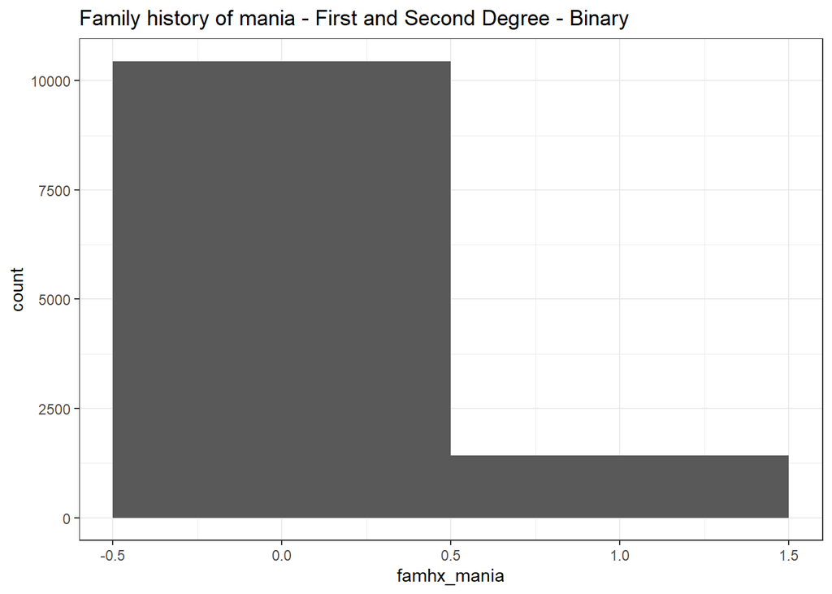

```r
ggplot(famhx, aes(x = famhx_mania))+
  geom_histogram(binwidth = 1)+
  ggtitle("Family history of mania - First and Second Degree - Binary")
```

### PLOT First and Second Degree Relatives, Sum Score

```r
table(famhx$sum_hx) #check sum score
```

```
##
##     0     1     2     3     4     5     6     7     8     9
## 10451  1050   253    69    20    15     4     2     3     1
```

```r
mean(na.omit(famhx$sum_hx))
```

```
## [1] 0.1675935
```

```r
sd(na.omit(famhx$sum_hx))
```

```
## [1] 0.5476884
```

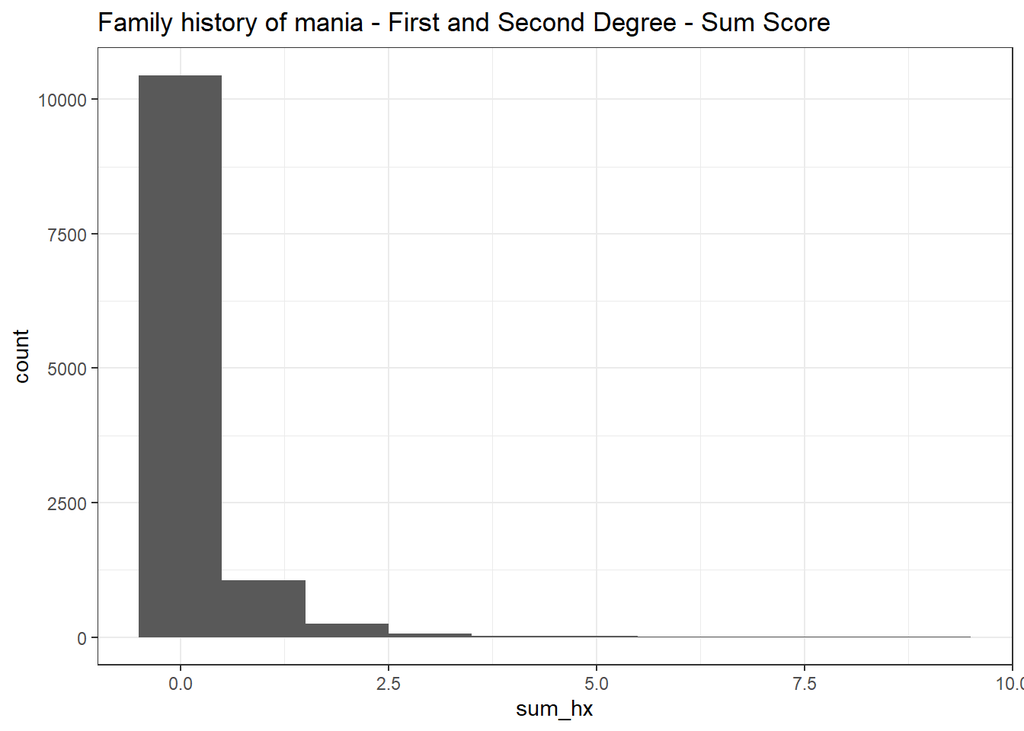

```r
ggplot(famhx, aes(x = sum_hx))+
  geom_histogram(binwidth = 1)+
  ggtitle("Family history of mania - First and Second Degree - Sum Score")
```

# Check Demographics

```r
load(file='E:/data/GBI_demographics.rdata')
GBI_demographics = subset(GBI_demographics, GBI_demographics$eventname == "baseline_year_1_arm_1")
```

### Sex

```r
table(GBI_demographics$demo_sex_v2)
```

```
##
##    1    2
## 6191 5677
```

```r
mean(na.omit(GBI_demographics$demo_sex_v2))
```

```
## [1] NA
```

### Ethnicity and Race

```r
# race
table(GBI_demographics$race)
```

```
##
##                   White  Black/African American American Indian/Alaskan
##                    7510                    1868                      62
##                 Pacific                   Asian          Other/Multiple
##                      15                     243                    2146
```

```r
# hispanic ethnicity
table(GBI_demographics$ethnicity)
```

```
##
## not_hispanic     hispanic
##         9293         2401
```

# RISK FACTOR DATASET

## Finalize Riskfactor Dataset

```r
riskfactors <-sleep %>% select(src_subject_id,eventname,sds_p_ss_total) %>%
  full_join(ibs) %>%
  full_join(asthma) %>%
  full_join(bmi_5_twelve) %>%  # bmi without outliers z > +/-5 or under life limit
  full_join(baby_data) %>%
  full_join(depression) %>%
  full_join(anxiety) %>%
  full_join(adhd) %>%
  full_join(opposition) %>%
  full_join(conduct) %>%
  full_join(stress) %>%
  full_join(ravlt) %>%
  full_join(conflict_p) %>%
  full_join(conflict_y) %>%
  full_join(trauma) %>%
  full_join(maltreatment_neglect) %>%
  full_join(fam_first)
## keep only relevant variables
riskfactors = subset(new_riskfactors, select = c("src_subject_id", "eventname", "sds_p_ss_total", "three_sum", "medhx_2a", "BMI", "pregnancy_binary", "obstetric_binary", "premature_binary", "smallbirth", "csection_binary", "cbcl_scr_dsm5_depress_r", "cbcl_scr_dsm5_anxdisord_r", "cbcl_scr_dsm5_adhd_r", "cbcl_scr_dsm5_opposit_r", "cbcl_scr_dsm5_conduct_r", "cbcl_scr_07_stress_r", "ravlt_learning", "fes_p_ss_fc", "fes_y_ss_fc", "total_PTSD", "mal_neglect", "family_mania"))
```

[output not shown]

```r
# keep only baseline
new_riskfactors = subset(new_riskfactors, new_riskfactors$eventname == "baseline_year_1_arm_1")
```

[output not shown]

```r
# save dataset
#save(new_riskfactors,file='data/new_riskfactors.rdata')
```

## Riskfactors: List of relevant variables

sds_p_ss_total = sleep  
three_sum = IBS  
medhx_2a = asthma  
BMI = bmi  
pregnancy_binary = any pregnancy complications  
obstetric_binary = any obstetric complications  
premature_binary = born early  
smallbirth = weight under 2.5kg at birth  
csection_binary = C-Section  
cbcl_scr_dsm5_depress_r = depression  
cbcl_scr_dsm5_anxdisord_r = anxiety  
cbcl_scr_dsm5_adhd_r = ADHD  
cbcl_scr_dsm5_opposit_r = Oppositional behavior  
cbcl_scr_dsm5_conduct_r = Conduct disorder behavior  
cbcl_scr_07_stress_r = Stress  
ravlt_learning = Ray Auditory Learning Test  
fes_p_ss_fc = Family Conflict - parent rating  
fes_y_ss_fc = Family Conflict - youth rating  
total_PTSD = Trauma  
mal_neglect = Maltreatment  
family_mania = any First_Degree Relatives

## Create 1 final dataset

```r
rm(list = ls()) # clean all previous datasets
load(file='E:/data/new_riskfactors.rdata')  # load all riskfactors
load(file='E:/data/20240912_ses.rdata')     # load socioeconomic status
load(file='E:/data/GBI_demographics.rdata') # load GBI and demographics

# join datasets
new_GBI_demographics_riskfactors = left_join(GBI_demographics, ses)
new_GBI_demographics_riskfactors = left_join(new_GBI_demographics_riskfactors, new_riskfactors)
# save dataset
#save(new_GBI_demographics_riskfactors, file = 'data/new_GBI_demographics_riskfactors.rdata')
```

## Prepare for MPlus

```r
rm(list = ls()) # clean all previous datasets
load(file = 'E:/data/new_GBI_demographics_riskfactors.rdata')
new_GBI_demographics_riskfactors %>% distinct(src_subject_id) %>% count() # this file has 11,868 participants
```

```
##       n
## 1 11868
```

```r
new_GBI_demographics_riskfactors <-new_GBI_demographics_riskfactors  %>% filter(!c(visit==3 |visit==4))
new_GBI_demographics_riskfactors %>% distinct(src_subject_id) %>% count() # still 11868 participants
```

```
##       n
## 1 11868
```

```r
new_GBI_demographics_riskfactors <- new_GBI_demographics_riskfactors %>% filter(!is.na(pgbi_p_ss_score))
new_GBI_demographics_riskfactors %>% distinct(src_subject_id) %>% count() # 11866 participants
```

```
##       n
## 1 11866
```

```r
new_GBI_demographics_riskfactors<-new_GBI_demographics_riskfactors %>% group_by(src_subject_id) %>%
  mutate(count=n()) %>%
  filter(count==3) %>% ungroup() %>%
  select(!c(eventname,count))
new_GBI_demographics_riskfactors %>% distinct(src_subject_id) %>% count() #10,634 participants (same as for the first MPLUS analysis)
```

```
## # A tibble: 1 × 1
##       n
##   <int>
## 1 10634
```

```r
# transform to wide format
data_wide<- new_GBI_demographics_riskfactors%>% pivot_wider(
  id_cols=c(src_subject_id, race,ethnicity,demo_sex_v2, income_to_needs), # these don't change over time
  names_from = visit,
  values_from = c(site,acs_raked_propensity_score,pgbi_p_ss_score,
                 sds_p_ss_total,                # sleep
                 three_sum,                     # IBS
                 medhx_2a,                      # asthma
                 BMI,                           # bmi
                 pregnancy_binary,              # any pregnancy complications
                 obstetric_binary,              # any obstetric complications
                 premature_binary,              # born early
                 smallbirth,                    # weight under 2.5kg at birth
                 csection_binary,               # C-Section
                 cbcl_scr_dsm5_depress_r,       # depression
                 cbcl_scr_dsm5_anxdisord_r,     # anxiety
                 cbcl_scr_dsm5_adhd_r,          # ADHD
                 cbcl_scr_dsm5_opposit_r,       # Oppositional behavior
                 cbcl_scr_dsm5_conduct_r,       # Conduct disorder behavior
                 cbcl_scr_07_stress_r,          # Stress
                 ravlt_learning,                # Ray Auditory Learning Test
                 fes_p_ss_fc,                   # Family Conflict - parent rating
                 fes_y_ss_fc,                   # Family Conflict - youth rating
                 total_PTSD,                    # Trauma
                 mal_neglect,                   # Maltreatment and Neglect (score of 2 questionnaires)
                 family_mania))                 # any First_Degree Relatives))

# add race dummy variable
library(fastDummies)
data_wide<-data_wide %>%
  dummy_cols(select_columns="race",remove_selected_columns = T,remove_first_dummy = T)


#Convert sex and ethnicity to numeric
data_wide<-data_wide %>% mutate(ethnicity=as.numeric(ethnicity),
                                demo_sex_v2=as.numeric(demo_sex_v2),
                                site_0=as.numeric(site_0))

#rearrange variables
data_wide<-data_wide %>% select(src_subject_id,site_0,acs_raked_propensity_score_0,
                                pgbi_p_ss_score_0, pgbi_p_ss_score_1, pgbi_p_ss_score_2 ,demo_sex_v2,
                                starts_with("race"),ethnicity, income_to_needs,
                                ends_with("_0"))


#replace missing with -99 (required for Mplus to work)
new_data_final<-data_wide %>% replace(is.na(.),-99)

##save data (id's included)
#setwd("E:")
#write.csv(new_data_final, file='code/MPLUS/new_data_predictors.csv',row.names = F)

##save data (id's and headers removed) ==> manually go into excel and remove headers
new_data_final <- new_data_final %>% select(-src_subject_id)
colnames(new_data_final)
```

```
##  [1] "site_0"                       "acs_raked_propensity_score_0"
##  [3] "pgbi_p_ss_score_0"            "pgbi_p_ss_score_1"
##  [5] "pgbi_p_ss_score_2"            "demo_sex_v2"
##  [7] "race_Black/African American"  "race_American Indian/Alaskan"
##  [9] "race_Pacific"                 "race_Asian"
## [11] "race_Other/Multiple"          "race_NA"
## [13] "ethnicity"                    "income_to_needs"
## [15] "sds_p_ss_total_0"             "three_sum_0"
## [17] "medhx_2a_0"                   "BMI_0"
## [19] "pregnancy_binary_0"           "obstetric_binary_0"
## [21] "premature_binary_0"           "smallbirth_0"
## [23] "csection_binary_0"            "cbcl_scr_dsm5_depress_r_0"
## [25] "cbcl_scr_dsm5_anxdisord_r_0"  "cbcl_scr_dsm5_adhd_r_0"
## [27] "cbcl_scr_dsm5_opposit_r_0"    "cbcl_scr_dsm5_conduct_r_0"
## [29] "cbcl_scr_07_stress_r_0"       "ravlt_learning_0"
## [31] "fes_p_ss_fc_0"                "fes_y_ss_fc_0"
## [33] "total_PTSD_0"                 "mal_neglect_0"
## [35] "family_mania_0"
```

```r
#write.csv(new_data_final, file='code/MPLUS/new_data_predictors_noheaders.csv',row.names = F,col.names = F)
```

# SLEEP DATASET

for post-hoc analysis only; not part of the main hypotheses

```r
sleep <- read_csv("E:/release_5.1/core/physical-health/ph_p_sds.csv")
```

```r
sleep = subset(sleep, select = c("src_subject_id", "eventname", "sds_p_ss_total", "sds_p_ss_dims",
"sds_p_ss_sbd", "sds_p_ss_da", "sds_p_ss_swtd", "sds_p_ss_does", "sds_p_ss_shy"))

sleep = subset(sleep, sleep$eventname == "baseline_year_1_arm_1") # select only baseline

sleep_dataset = subset(sleep, select = c ("src_subject_id", "eventname", "sds_p_ss_dims", "sds_p_ss_sbd", "sds_p_ss_da", "sds_p_ss_swtd", "sds_p_ss_does", "sds_p_ss_shy"))

# save dataset
# save(sleep_dataset,file='data/sleep_dataset.rdata')

# Create one final dataset
load(file='E:/data/20240912_ses.rdata')     # load socioeconomic status
load(file='E:/data/GBI_demographics.rdata') # load GBI and demographics

# join datasets
sleep_with_GBIdemographics = left_join(GBI_demographics, ses)
sleep_with_GBIdemographics = left_join(sleep_with_GBIdemographics, sleep_dataset)
# save dataset
# save(sleep_with_GBIdemographics, file = 'data/sleep_with_GBIdemographics.rdata')
```

## Prepare Sleep Dataset for MPlus

```r
rm(list = ls()) # clean all previous datasets
load(file = 'E:/data/sleep_with_GBIdemographics.rdata')
sleep_with_GBIdemographics %>% distinct(src_subject_id) %>% count() # this file has 11,868 participants
```

```
##       n
## 1 11868
```

```r
sleep_with_GBIdemographics <-sleep_with_GBIdemographics  %>% filter(!c(visit==3 |visit==4))
sleep_with_GBIdemographics %>% distinct(src_subject_id) %>% count() # still 11868 participants
```

```
##       n
## 1 11868
```

```r
sleep_with_GBIdemographics <- sleep_with_GBIdemographics %>% filter(!is.na(pgbi_p_ss_score))
sleep_with_GBIdemographics %>% distinct(src_subject_id) %>% count() # 11866 participants
```

```
##       n
## 1 11866
```

```r
sleep_with_GBIdemographics<-sleep_with_GBIdemographics %>% group_by(src_subject_id) %>%
  mutate(count=n()) %>%
  filter(count==3) %>% ungroup() %>%
  select(!c(eventname,count))
sleep_with_GBIdemographics %>% distinct(src_subject_id) %>% count() #10,634 participants (same as for the first MPLUS analysis)
```

```
## # A tibble: 1 × 1
##       n
##   <int>
## 1 10634
```

```r
# transform to wide format
data_wide<- sleep_with_GBIdemographics%>% pivot_wider(
  id_cols=c(src_subject_id, race,ethnicity,demo_sex_v2, income_to_needs), # these don't change over time
  names_from = visit,
  values_from = c(site,acs_raked_propensity_score,pgbi_p_ss_score,
                 sds_p_ss_dims, # Sleep Subscale - Disorders of Initiating and Maintaining Sleep
                 sds_p_ss_sbd,  # Sleep Subscale - Sleep Breathing disorders
                 sds_p_ss_da,   # Sleep Subscale - Disorder of Arousal
                 sds_p_ss_swtd, # Sleep Subscale - Sleep-Wake transition Disorders
                 sds_p_ss_does, # Sleep Subscale - Disorders of Excessive Somnolence
                 sds_p_ss_shy)) # Sleep Subscale - Sleep Hyperhydrosis

# add race dummy variable
library(fastDummies)
data_wide<-data_wide %>%
  dummy_cols(select_columns="race",remove_selected_columns = T,remove_first_dummy = T)


#Convert sex and ethnicity to numeric
data_wide<-data_wide %>% mutate(ethnicity=as.numeric(ethnicity),
                                demo_sex_v2=as.numeric(demo_sex_v2),
                                site_0=as.numeric(site_0))

#rearrange variables
data_wide<-data_wide %>% select(src_subject_id,site_0,acs_raked_propensity_score_0,
                                pgbi_p_ss_score_0, pgbi_p_ss_score_1, pgbi_p_ss_score_2 ,demo_sex_v2,
                                starts_with("race"),ethnicity, income_to_needs,
                                ends_with("_0"))


#replace missing with -99 (required for Mplus to work)
new_data_final<-data_wide %>% replace(is.na(.),-99)
```

## Save Sleep Dataset

Save the dataset with IDs for clarity and without IDs and headers for Mplus analysis.

```r
sleep_dataset = new_data_final

##save data (id's included)
#write.csv(sleep_dataset, file='code/MPLUS/sleep_dataset.csv',row.names = F)

##save data (id's and headers removed)
sleep_dataset <- sleep_dataset %>% select(-src_subject_id)
colnames(sleep_dataset)
```

```
##  [1] "site_0"                       "acs_raked_propensity_score_0"
##  [3] "pgbi_p_ss_score_0"            "pgbi_p_ss_score_1"
##  [5] "pgbi_p_ss_score_2"            "demo_sex_v2"
##  [7] "race_Black/African American"  "race_American Indian/Alaskan"
##  [9] "race_Pacific"                 "race_Asian"
## [11] "race_Other/Multiple"          "race_NA"
## [13] "ethnicity"                    "income_to_needs"
## [15] "sds_p_ss_dims_0"              "sds_p_ss_sbd_0"
## [17] "sds_p_ss_da_0"                "sds_p_ss_swtd_0"
## [19] "sds_p_ss_does_0"              "sds_p_ss_shy_0"
```

```r
#write.csv(sleep_dataset, file='code/MPLUS/sleep_dataset_noheaders.csv',row.names = F,col.names = F)
```